# 02 Exercises

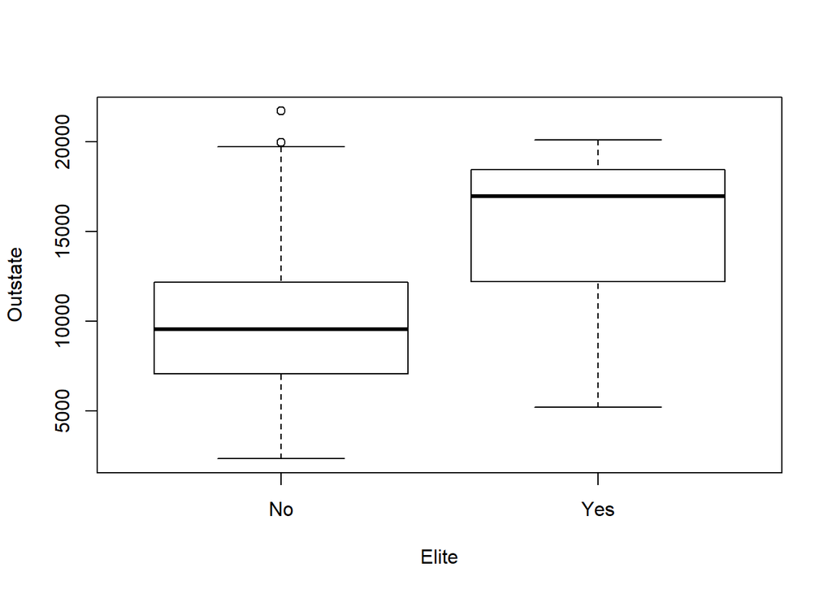

```r
plot(college$Elite, college$Outstate, xlab = "Elite", ylab = "Outstate")
```

Use the **hist()** function to produce some histograms with differing numbers of bins for a few of the quantitative variables. You may find the command **par(mfrow=c(2,2))** useful: it will divide the print window into four regions so that four plots can be made simultaneously. Modifying the arguments to this function will divide the screen in other ways.

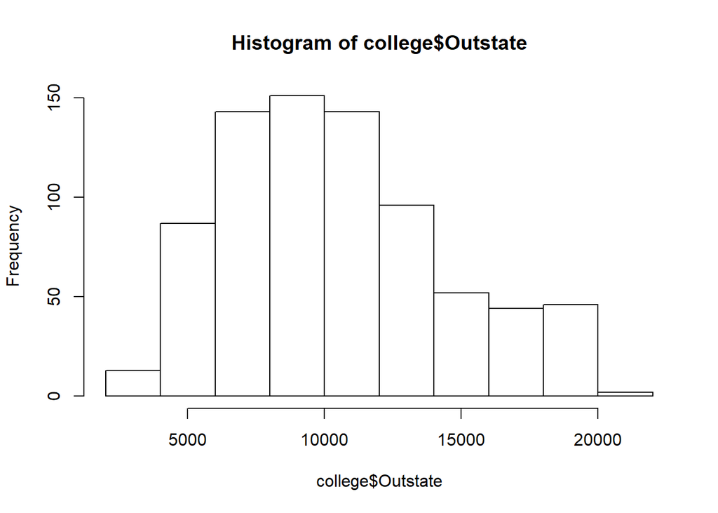

```r
hist(college$Outstate)
```

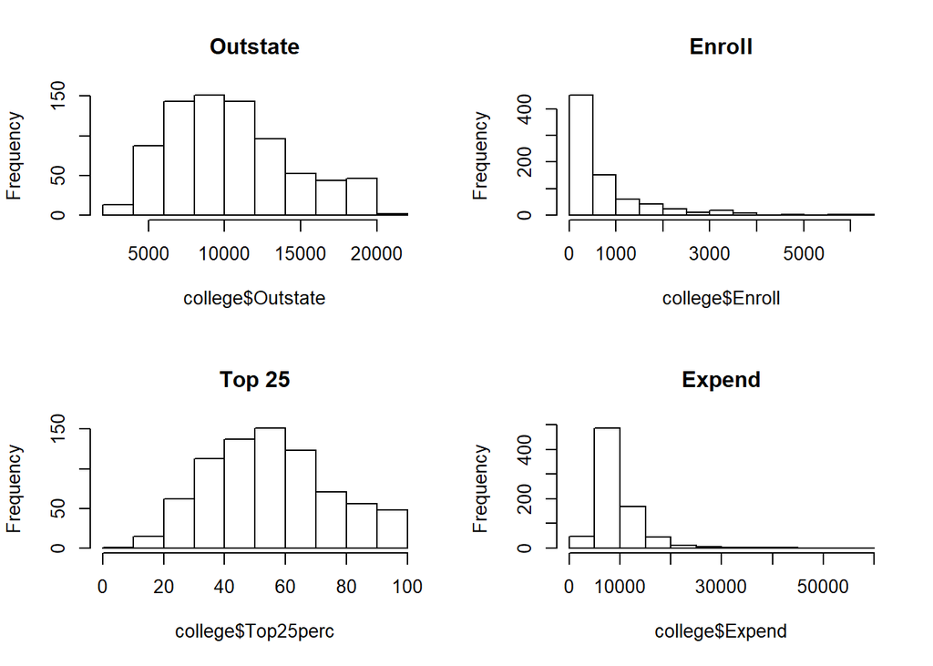

```r
par(mfrow = c(2, 2))
hist(college$Outstate, main = "Outstate")
hist(college$Enroll, main = "Enroll")
hist(college$Top25perc, main = "Top 25")
hist(college$Expend, main = "Expend")
```

Continue exploring the data, and provide a brief summary of what you discover.

### Problem 9

This exercise involves the **Auto** data set studied in the lab. Make sure that the missing values have been removed from the data.

```r
auto <- read.csv("data/Auto.csv", header = TRUE, na.strings = "?")
```

Which of the predictors are quantitative, and which are qualitative?

```r
summary(auto)
```

```
##       mpg          cylinders      displacement     horsepower
##  Min.   : 9.00   Min.   :3.000   Min.   : 68.0   Min.   : 46.0
##  1st Qu.:17.50   1st Qu.:4.000   1st Qu.:104.0   1st Qu.: 75.0
##  Median :23.00   Median :4.000   Median :146.0   Median : 93.5
##  Mean   :23.52   Mean   :5.458   Mean   :193.5   Mean   :104.5
##  3rd Qu.:29.00   3rd Qu.:8.000   3rd Qu.:262.0   3rd Qu.:126.0
##  Max.   :46.60   Max.   :8.000   Max.   :455.0   Max.   :230.0
##                                                  NA's   :5
##      weight      acceleration        year           origin
##  Min.   :1613   Min.   : 8.00   Min.   :70.00   Min.   :1.000
##  1st Qu.:2223   1st Qu.:13.80   1st Qu.:73.00   1st Qu.:1.000
##  Median :2800   Median :15.50   Median :76.00   Median :1.000
##  Mean   :2970   Mean   :15.56   Mean   :75.99   Mean   :1.574
##  3rd Qu.:3609   3rd Qu.:17.10   3rd Qu.:79.00   3rd Qu.:2.000
##  Max.   :5140   Max.   :24.80   Max.   :82.00   Max.   :3.000
##
##              name
##  ford pinto    :  6
##  amc matador   :  5
##  ford maverick :  5
##  toyota corolla:  5
##  amc gremlin   :  4
##  amc hornet    :  4
##  (Other)       :368
```

```r
str(auto)
```

```
## 'data.frame':    397 obs. of  9 variables:
##  $ mpg         : num  18 15 18 16 17 15 14 14 14 15 ...
##  $ cylinders   : int  8 8 8 8 8 8 8 8 8 8 ...
##  $ displacement: num  307 350 318 304 302 429 454 440 455 390 ...
##  $ horsepower  : int  130 165 150 150 140 198 220 215 225 190 ...
##  $ weight      : int  3504 3693 3436 3433 3449 4341 4354 4312 4425 3850 ...
##  $ acceleration: num  12 11.5 11 12 10.5 10 9 8.5 10 8.5 ...
##  $ year        : int  70 70 70 70 70 70 70 70 70 70 ...
##  $ origin      : int  1 1 1 1 1 1 1 1 1 1 ...
##  $ name        : Factor w/ 304 levels "amc ambassador brougham",..: 49 36 231 14 161 141 54 223 241 2 ...
```

```
Quantitative Predictors - mpg, displacement, horsepower, weight, acceleration
Qualitativve Predictors - cylinders, year, origin, name
```

What is the range of each quantitative predictor? You can answer this using the **range()** function.

```r
sapply(auto[, -c(2, 7, 8, 9)], range, na.rm = TRUE)
```

```
##       mpg displacement horsepower weight acceleration
## [1,]  9.0           68         46   1613          8.0
## [2,] 46.6          455        230   5140         24.8
```

What is the mean and standard deviation of each quantitative predictor?

```r
sapply(auto[, -c(2, 7, 8, 9)], mean, na.rm = TRUE)
```

```
##          mpg displacement   horsepower       weight acceleration
##     23.51587    193.53275    104.46939   2970.26196     15.55567
```

```r
sapply(auto[, -c(2, 7, 8, 9)], sd, na.rm = TRUE)
```

```
##          mpg displacement   horsepower       weight acceleration
##     7.825804   104.379583    38.491160   847.904119     2.749995
```

Now remove the 10th through 85th observations. What is the range, mean, and standard deviation of each predictor in the subset of the data that remains?

```r
sapply(auto[-c(10:85), -c(2, 7, 8, 9)], range, na.rm = TRUE)
```

```
##       mpg displacement horsepower weight acceleration
## [1,] 11.0           68         46   1649          8.5
## [2,] 46.6          455        230   4997         24.8
```

```r
sapply(auto[-c(10:85), -c(2, 7, 8, 9)], mean, na.rm = TRUE)
```

```
##          mpg displacement   horsepower       weight acceleration
##     24.43863    187.04984    100.95584   2933.96262     15.72305
```

```r
sapply(auto[-c(10:85), -c(2, 7, 8, 9)], sd, na.rm = TRUE)
```

```
##          mpg displacement   horsepower       weight acceleration
##     7.908184    99.635385    35.895567   810.642938     2.680514
```

Using the full data set, investigate the predictors graphically, using scatterplots or other tools of your choice. Create some plots highlighting the relationships among the predictors. Comment on your findings.

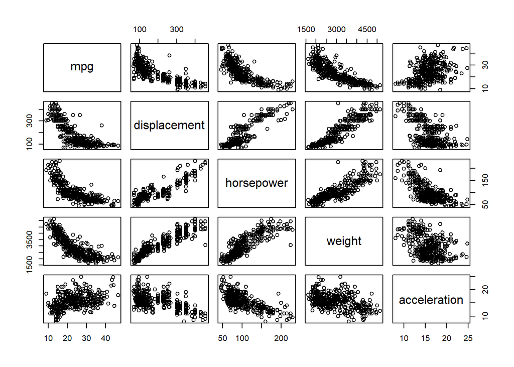

```r
pairs(auto[, -c(2, 7, 8, 9)])
```

Suppose that we wish to predict gas mileage (**mpg**) on the basis of the other variables. Do your plots suggest that any of the other variables might be useful in predicting **mpg**? Justify your answer.

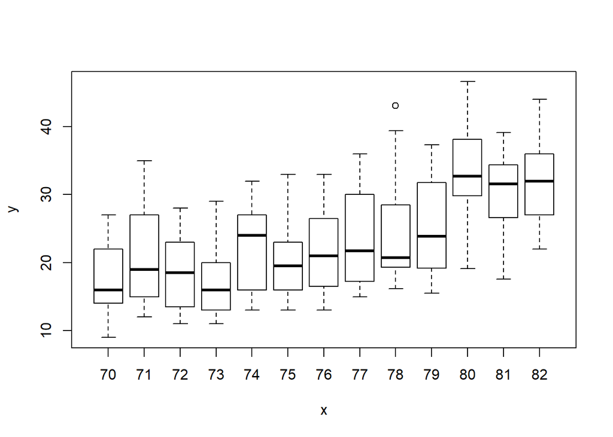

```r
plot(as.factor(auto$year), auto$mpg)
```

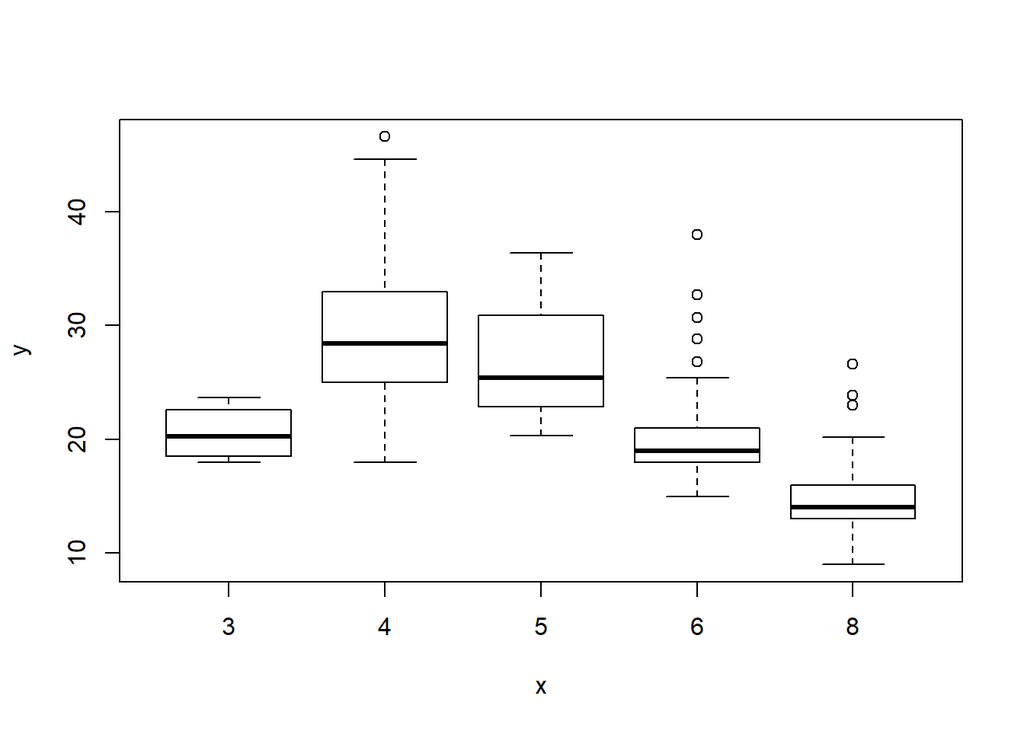

```r
plot(as.factor(auto$cylinders), auto$mpg)
```

```r
cor(auto[, -9], use = "pairwise.complete.obs")
```

```
##                     mpg  cylinders displacement horsepower     weight
## mpg           1.0000000 -0.7762599   -0.8044430 -0.7784268 -0.8317389
## cylinders    -0.7762599  1.0000000    0.9509199  0.8429834  0.8970169
## displacement -0.8044430  0.9509199    1.0000000  0.8972570  0.9331044
## horsepower   -0.7784268  0.8429834    0.8972570  1.0000000  0.8645377
## weight       -0.8317389  0.8970169    0.9331044  0.8645377  1.0000000
## acceleration  0.4222974 -0.5040606   -0.5441618 -0.6891955 -0.4195023
## year          0.5814695 -0.3467172   -0.3698041 -0.4163615 -0.3079004
## origin        0.5636979 -0.5649716   -0.6106643 -0.4551715 -0.5812652
##              acceleration       year     origin
## mpg             0.4222974  0.5814695  0.5636979
## cylinders      -0.5040606 -0.3467172 -0.5649716
## displacement   -0.5441618 -0.3698041 -0.6106643
## horsepower     -0.6891955 -0.4163615 -0.4551715
## weight         -0.4195023 -0.3079004 -0.5812652
## acceleration    1.0000000  0.2829009  0.2100836
## year            0.2829009  1.0000000  0.1843141
## origin          0.2100836  0.1843141  1.0000000
```